# Response curve, threshold, tipping point models

GES4SEAS Work Package 4

Task 4.3 Inclusion of response curves and threshold models

# Introduction

This aim of the this document is to catalogue and describe the forms of models which we envisage for inclusion in the GES4SEAS toolbox.

At present we are working with two main types of tools:

- **status** assessment
- **combined** (or *cumulative*) **effect** (or *impact*) assessment

## Status assessment

This form of tool aims to determine the absolute condition of the ecosystem i.e. for example is the state *good* or *not good*. There are many examples of this kind of tool. The GES4SEAS toolbox implements one of these - the [NEAT tool](https://www.azti.es/en/productos/neat-software-nested-environmental-status-assessment-tool/). This is a flexible tool which can makes use of a wide variety of indicator parameters at differing spatial resolutions.

The principle of *NEAT* and similar tools is the comparison of the observed values of one or more indicator parameters with agreed threshold values or reference points which determine the boundary between good and not-good states. For example, the average measured concentration of chlorophyll *a* can be used as an indicator of eutrophication.

A further typical feature of these tools is a method to aggregate the results of several indicators in categories or across spatial scales and classify the results to arrive at an overall *integrated status assessment*.

## Cumulative effect assessment

This form of tool provides a quantitative measure of the combined effects on ecosystems of the pressures resulting from many types of human activity. This can indicate how the combined effects vary spatially and show that they are relatively higher in one location or region than in another. They do not at present predict status or health of ecosystems based on the levels of pressure intensity.

This form of tool is data hungry, using spatial data which maps the distribution of species and habitats as well as the distribution of pressures acting on these ecosystem components.

## Unified assessment tools

The ultimate aim of assessment tools is to guide the management of human activities so that the effects of the resulting pressures on ecosystem health are kept within limits which prevent the deterioration of healthy ecosystems and which allow those ecosystems not in a healthy state to recover.

To that end, the similar goals of (i) being able to predict the resulting state of ecosystems given a set of pressures or (ii) to quantify necessary reductions in pressures required to ensure the maintenance of or return to good status in ecosystems would both require linkages between pressure levels and ecosystem health.

Work is ongoing in the GES4SEAS project to combine the status assessment functionality of the NEAT tool with the cumulative assessment methods. Whilst the tool may not be able to predict explicitly the status resulting from certain levels of pressures, the combination of the two types of tool in GES4SEAS brings this goal little closer.

# Response models

## Simple linear responses

In the [Halpern *et al.* (2008)](https://www.science.org/doi/10.1126/science.1149345) method, the *impact* of a pressure on an ecosystem component is given by the product of the pressure intensity and a constant, the *sensitivity score*. This implies that there is a linear relationship between the intensity of a pressure and its effect on the ecosystem component.

### One pressure one ecosystem component

Ignoring spatial resolution for a moment, if we consider the effects resulting from a number of normalised pressures acting on ecosystem components then the effect $I_{ij}$ resulting from pressure $j$ acting on the ecosystem component $i$ is:

$$I_{ij} = D_i *e_j * µ_{ij}
\tag{1}$$

where:

$D_i$ is the *intensity* of pressure $i$

$e_j$ is the *quantity* or *level* of ecosystem $j$

$µ_{ij}$ is the *sensitivity* of ecosystem component $j$ to pressure $i$

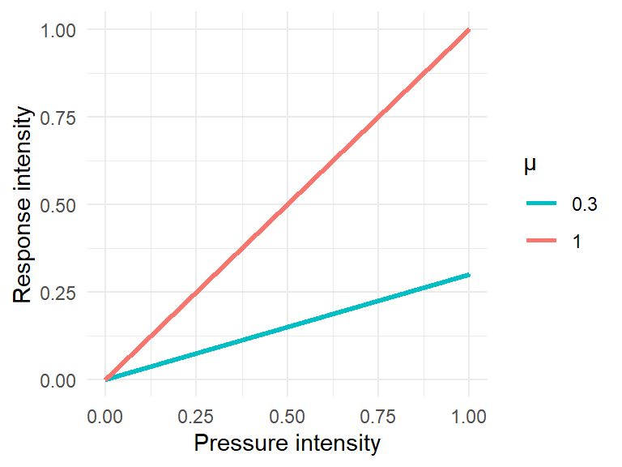

Figure 1: Linear response to single pressure varies with sensitivity, µ

Figure 1 shows how the estimated effect varies with increasing pressure intensity for two different values of sensitivity $µ$.

### Multiple pressures and ecosystem components

$$I_{sum}(x,y) = \sum_{i=1}^{n}\sum_{j=1}^{m}{D_i(x,y) *e_j(x,y) * µ_{ij}}
\tag{2}$$

Similarly to Equation 1:

$D_i(x,y)$ i the *intensity* of pressure $i$ in the grid cell $x,y$

$e_j(x,y)$ is the *quantity* or *level* of ecosystem $j$ in the grid cell $x,y$

$µ_{ij}$ is the *sensitivity* of ecosystem component $j$ to pressure $i$

By normalising the sum of effects to the ecosystem diversity, we obtain the (*mean*) version of the Halpern *et al* assessment:

$$I_{mean}(x,y) = \sum_{i=1}^{n}\sum_{j=1}^{m}{\frac{1}{E_{div}(x,y)}}{D_i(x,y) *e_j(x,y) * µ_{ij}}
\tag{3}$$

where $E_{div}$ the ecosystem diversity index is given by:

$$E_{div}(x,y) = \sum_{j=1}^{m}e_j(x,y)
\tag{4}$$

### Normalisation of pressure intensities and ecosystem component *quantities*

The simplest form of quantification of an ecosystem component or a pressure is a simple presence/absence - assigning a $0$ or $1$ value.

A comparison of the products of noise intensities (dB) and population counts with the products of nutrient concentrations and dimensionless quality indices is not meaningful. We need to transform the observed quantities onto some comparable scales.

Figure 2 shows the distribution of intensity, as absolute values, for a pressure across an area of interest. This could be, for example, the distribution of all values in the raster grid cells of a data layer representing concentration of a nutrient [mg l<sup>-1</sup>].

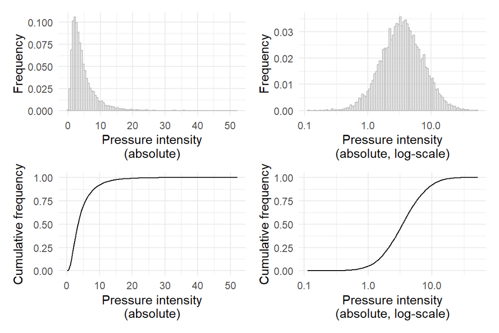

Figure 2: A pressure with lognormal intensity distribution

We can normalise the pressure intensities by log-transforming them and rescaling from $0$ to $1$:

$$D^{'} = \frac{ln(D+1) - ln(D_{min}+1)}{ln(D_{max}+1)-ln(D_{min}+1)}
\tag{5}$$

Alternative methods include truncation at percentile values (e.g, 99th) to exclude outliers, before log-transformation and rescaling:

$$D^{'} = \frac{ln(D+1) - ln(D_{1\%}+1)}{ln(D_{99\%}+1)-ln(D_{1\%}+1)}$$

### Product of ecosystem and pressure

There is a linear relationship between the pressure intensity, $D$ and the estimated effect $I$. This assumes a given ecosystem level value $e$. For a given pressure intensity, $D$, there is also a linear relationship between the ecosystem level value $e$ and the effect.

The variation in effect with pressure intensity and ecosystem value can be shown in a heat map.

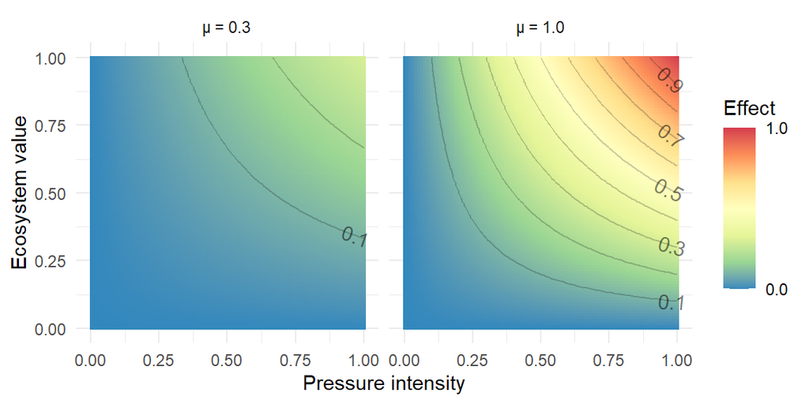

Figure 3: Effect vs normalised pressure and ecosystem component values

## Non-linear responses

### Thresholds and logistic functions

When talking about thresholds in the context of ecosystem response to a pressure, we are considering a pressure where it has no effect below a certain level. With increasing pressure, no effect is seen until we approach the the threshold level. The response increases with increasing pressure. Finally we could consider that a maximium effect is reached at a certain pressure level. Beyond this, any further increases in pressure do not cause the response to increase beyond this maximum level.

The response to a pressure as outlined here, with a threshold pressure level and maximum response, can be described using a logisitc function. The generalized logistic function can be written:

$$f(x)=\frac{L}{1+e^{-k(x-x_0)}}
\tag{6}$$

For the case where $L=1$, the function varies between $0$ and $1$. Figure 4 shows the function for $x_0=0.5$ and for 3 different values of $k$:

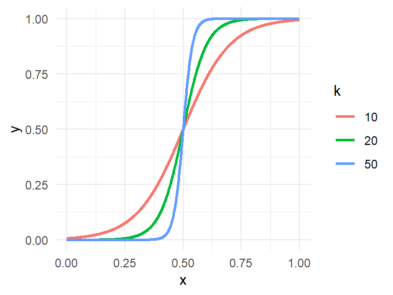

Figure 4: A general logistic function

### Other non-linear responses

There are many other non-linear functions which could be relevant for representing ecosystem responses to pressures. Some of the more common ones are outlined briefly here. Others not shown, include power functions, Weibull functions.

#### log functions

Figure 5 shows functions with the general form

$$f(x)=a + b\operatorname{log}(x) \tag{7}$$

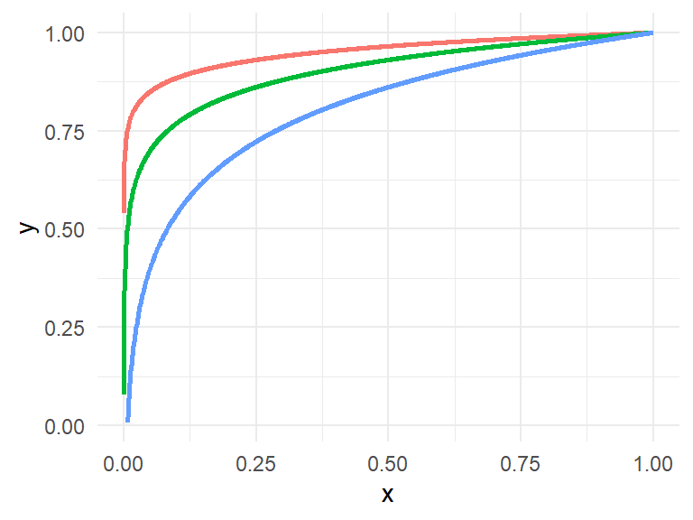

Figure 5: Logarithmic functions

#### exponential functions

Functions having the general form of the exponential are shown in Figure 6:
$$f(x)=A e^{kx} \tag{8}$$

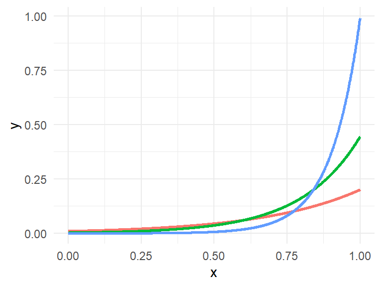

Figure 6: Exponential functions

Comparing with Figure 4, we can see similarity between the exponential function and the growth phase of the logistic function where $x \lt x_0$.

#### negative exponential functions

The negative exponential function has the general form
$$f(x)=1-e^{-kx} \tag{9}$$

This is illustrated in Figure 7.

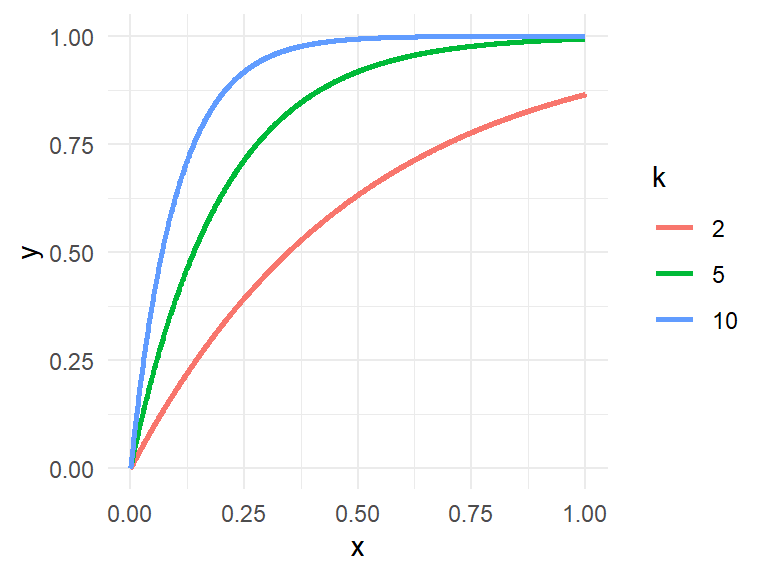

Figure 7: Negative exponential function

## Multivariate responses

In the current implementation of the GES4SEAS tool, the effect of pressures on ecosystem components is calculated separately for each unique combination of pressure and ecosystem component. The combined result is then calculated by simple addition of individual contributions. For the Halpern *mean* method, the sum is then normalised to the quantity or number of ecosystem components but there is no interaction between pressures. The *EcoImpactMapper* tool allows for testing if the effects of interactions between stressors are potentially important for the results of a cumulative effect assessment [Stock & Micheli 2016](https://doi.org/10.1111/geb.12493).

Figure 8 illustrates how the separate responses of two different pressures *left* can be combined by interaction *right*. An antagonistic interaction where the effect of one pressure is counteracted or reduced by the other pressure is shown by the blue curve $f_{12}(x)=f_1(x) * (1 - f_2(x))$ whilst the red curve illustrates how the combined response is greater than either of the individual responses the $f_{12}(x)= 1 - (1-f_1(x)) * (1 - f_2(x)))$.

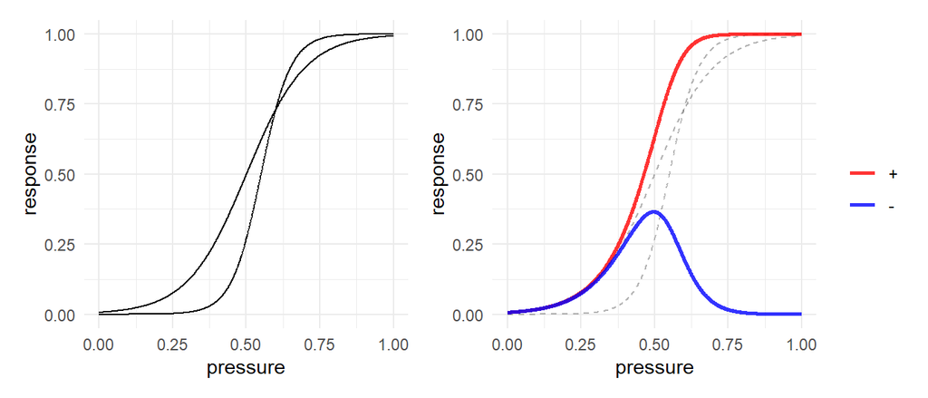

Figure 8: Two pressure response curves (left) and potential interactions (right)

## Fitting pressure-response functions

We need to find the function which best describes the response of an ecosystem component to increasing intensity of a pressure.

### Threshold functions

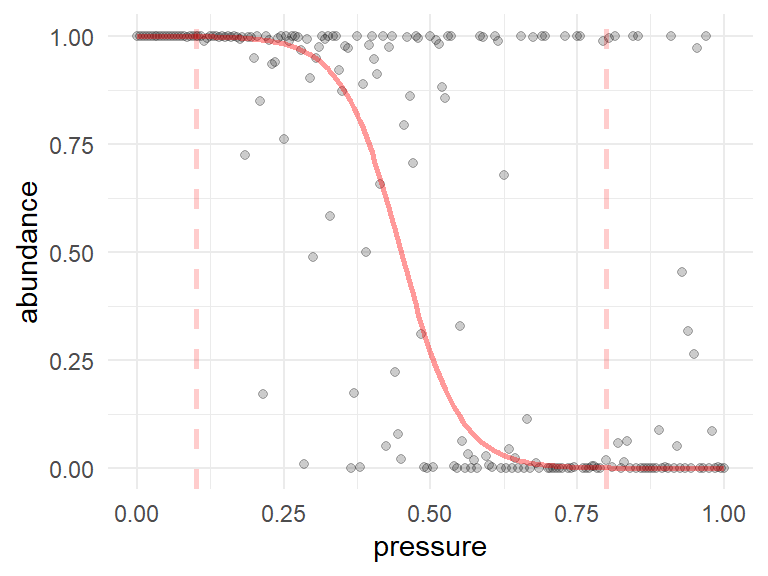

Figure 9: Abundance of a species versus pressure intensity

Given the knowledge about the range of pressure values where the species shows a response, we can formulate a pressure-response function to describe how the impact on the species varies Figure 10

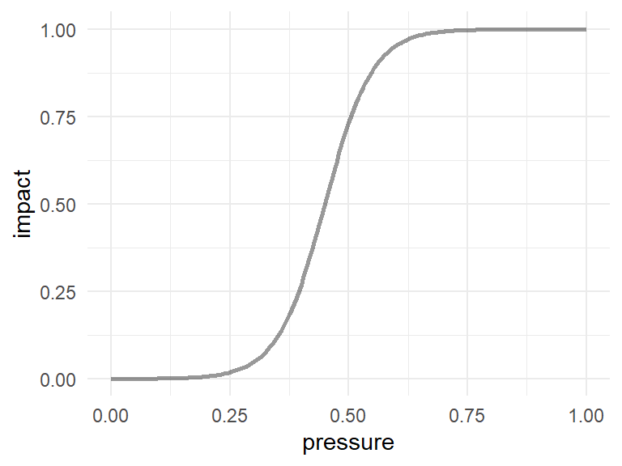

Figure 10: Species response to pressure intensity

### Threshold function - a piecewise linear approximation

The logistic function can be approximated by a piece-wise linear function with two fixed points. For general case where $y$ can vary outside the range $0-1$, the equation can be written:

$$f(x)=\begin{cases} y_0, & x \le x_0 \\ y_0 + {(y_1 - y_0) (\frac{x - x_0}{x_1 - x_0} )}, & x_0 \lt x \le x_1 \\ y_1, & x \gt x_1 \end{cases}$$

For the case where $y$ varies in the range $0-1$:

$$f(x)=\begin{cases} 0, & x \le x_0 \\
\frac{x - x_0}{x_1 - x_0}, & x_0 \lt x \le x_1 \\
1, & x \gt x_1 \end{cases}
\tag{10}$$

Figure 11 shows how the logistic function for $k=20$ can be approximated by a piece-wise linear function.

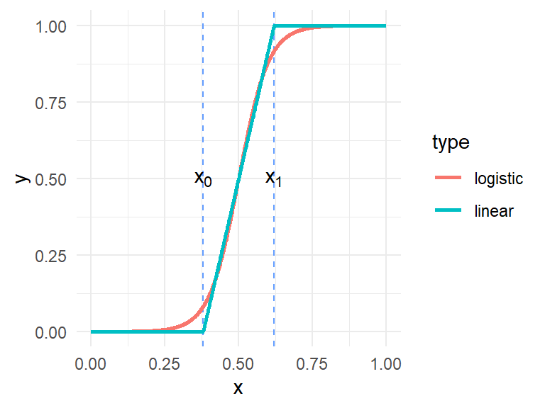

Figure 11: A piece-wise linear approximation of a logistic function

By selecting the appropriate parameters, piece-wise linear functions can be used to represent other functional relationship, including thresholds, where a pressure has no effect below a certain intensity or where its effect does not increase above a certain limit:

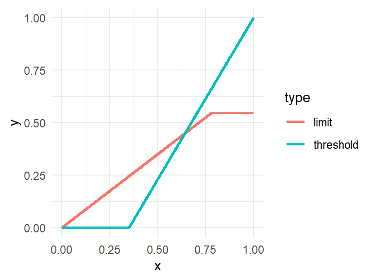

Figure 12: Piece-wise linear threshold functions

### A generalized piecewise linear function

In many cases the functions can be approximated by linear piece-wise functions. The number of segments in the piece-wise function can be increased to give a closer fit to the original function:

$$f(x)=\begin{cases} y_0, & x \le x_0 \\ y_0 + {(y_1 - y_0) (\frac{x - x_0}{x_1 - x_0} )}, & x_0 \lt x \le x_1 \\ y_1 + {(y_2 - y_1) (\frac{x - x_1}{x_2 - x_1} )}, & x_1 \lt x \le x_2 \\ ... \\ y_{n-1} + {(y_{n} - y_{n-1}) (\frac{x - x_{n-1}}{x_{n} - x_{n-1}} )}, & x_{n-1} \lt x \le x_{n} \\y_n, & x \gt x_n \end{cases} \tag{11}$$

# Algorithms

The assessment methods must be converted into operational code. The GES4SEAS toolbox uses the [tcl](https://www.tcl-lang.org/) programming language but the algorithms can be generalized and written in many different languages. The examples here are written in **R**:

## No spatial interactions

With many data layers and a fine spatial resolution, the computational effort can still be large but the method remains quite simple. The core calculations for the ‘Halpern’ method ( Equation 2 and Equation 3) can be written in relatively few lines of code.

Since there is no spatial interaction, each 2-dimensional grid cell can be assigned an id number. All 2-dimensional arrays then be arranged as 1-dimensional lists. After calculations are completed the position in the list can be used to retrieve information about the grid cells and convert the 1-dimensional results back to 2-dimensional maps.

```r
# p[i, k]   # pressure intensity for pressure i in grid cell k
# ec[j, k]  # ecosystem level for component j in grid cell k
# mu[i, k]  # sensitivity of ecosystem component j to pressure i
# I_sum[k]  # the sum of effects in grid cell k
# I_mean[k] # the sum of effects in grid cell k normalised to E_div
# E_div(k)  # the ccosystem diversity in cell k

# loop through each grid cell
for(k in 1:length(gridcells)){

  # initialise the sum of effects for this cell
  I_sum[k] <- 0

  # initialise the ecosystem diversity
  E_div[k] <- 0

  # loop through each ecosystem component
  for(j in 1:length(ecosystem_components)){

    # check if the ecosystem component value >0
    # otherwise no calculations are required
    if(ec[j,k] > 0){
      E_div[k] <- E_div[k] +  ec[j,k]

      # loop through each pressure
      for(i in 1:length(pressures)){
        I_sum[k] <- I_sum[k] + p[i,k] * ec[j,k] * mu[i,j]
      }
    }
  }

  # if E_div > 0 then divide the I_sum by E_div to get I_mean
  if(E_div[k]>0){
      I_mean[k] <- I_sum[k] / E_div[k]
  }else{
    I_mean[k] <- 0
  }
}
```

The algorithm as written here is intended purely to demonstrate the simplicity of the calculation required. There is plenty of room for improvement. For example, the use of loops is quite inefficient when matrix and parallel operations could be used instead.

## Spatial Interactions

The models implemented in the GES4SEAS tool consider only the information for values of ecosystem components and pressures in the grid cell or assessment unit in question when estimating the cumulative effect. For example, the effect of a contaminant which spreads from a source to affect ecosystems located *at distance* from the source can only be included in a cumulative effect assessment by modelling explicitly the spread of the contaminant from source to the point where cumulative effects are being estimated. This may be a complex hydrodynamic and advection/dispersion simulation or a coarse approximation using distance decay function but some form of explicit mapping of the spatial distribution of the pressure is necessary.

Including potential effects of pressures outside the grid cells / assessment units in which they occur is not possible.